# Data 606 HW 4 (Foundations for inference)

Monu Chacko

March 16, 2019

### Question 4.4

1. What is the point estimate for the average height of active individuals? What about the median?

### Answer:

#### Mean = 171.1

#### Median = 170.3

2. What is the point estimate for the standard deviation of the heights of active individuals? What about the IQR?

### Answer:

#### SD = 9.4

#### IQR = Q3 -Q1; 177.8-163.8 or 14

3. Is a person who is 1m 80cm (180 cm) tall considered unusually tall? And is a person who is 1m 55cm (155cm) considered unusually short? Explain your reasoning.

### Answer:

#### A person who is 180cm is considered tall because he/she is beyond third quartile (Q3). A person who is 155cm is considered short because he/she is below the first quartile (Q1).

4. The researchers take another random sample of physically active individuals. Would you expect the mean and the standard deviation of this new sample to be the ones given above? Explain your reasoning.

### Answer:

```r
9.4/sqrt(507)
```

```
## [1] 0.4174687
```

### Question 4.14

4.14 Thanksgiving spending, Part I. The 2009 holiday retail season, which kicked o??? on November 27, 2009 (the day after Thanksgiving), had been marked by somewhat lower self-reported consumer spending than was seen during the comparable period in 2008. To get an estimate of consumer spending, 436 randomly sampled American adults were surveyed. Daily consumer spending for the six-day period after Thanksgiving, spanning the Black Friday weekend and Cyber Monday, averaged $84.71. A 95% confidence interval based on this sample is ($80.31, $89.11). Determine whether the following statements are true or false, and explain your reasoning.

1. We are 95% confident that the average spending of these 436 American adults is between $80.31 and $89.11.

### Answer:

#### False. From the given data we are 100% confident.

2. This confidence interval is not valid since the distribution of spending in the sample is right skewed.

### Answer:

#### True. The right skewed indicates that we are away from the mean.

3. 95% of random samples have a sample mean between $80.31 and $89.11.

### Answer:

#### False. It is awayfrom the mean. The right skew indicates that.

4. We are 95% confident that the average spending of all American adults is between $80.31 and $89.11.

### Answer:

#### True. This is as shown by the data and the shape of the curve.

5. A 90% confidence interval would be narrower than the 95% confidence interval since we don’t need to be as sure about our estimate.

### Answer:

#### True. The 90% interval shows less confidence.

6. In order to decrease the margin of error of a 95% confidence interval to a third of what it is now, we would need to use a sample 3 times larger.

### Answer:

#### False. Larger dataset would decrease the margin of error than a samller sample dataset.

7. The margin of error is 4.4.

### Answer:

#### True. it is 4.4

```r
u = 89.11
l = 80.31
me =(u -l)/2
me
```

```
## [1] 4.4
```

### Question 4.24

1. Are conditions for inference satisfied?

### Answer:

#### Yes they are satisfied. The data is not skewed. The observations are independent. The sample size is greater than or equal to 30.

2. Suppose you read online that children first count to 10 successfully when they are 32 months old, on average. Perform a hypothesis test to evaluate if these data provide convincing evidence that the average age at which gifted children fist count to 10 successfully is less than the general average of 32 months. Use a significance level of 0.10.

### Answer:

```r
normalPlot <- function(mean=0, sd=1, bounds=c(-1,1), tails=FALSE) {
    x <- seq(-4,4,length=100)*sd + mean
    hx <- dnorm(x,mean,sd)

    plot(x, hx, type="n", xlab="x-Axis", ylab="",
         main="Normal Distribution", axes=FALSE)
    lines(x, hx)

    if(tails) {
        i.low <- x <= bounds[1]
        i.high <- x >= bounds[2]
        polygon(c(x[i.low],bounds[1]), c(hx[i.low], 0), col="red")
        polygon(c(bounds[2],x[i.high]), c(0,hx[i.high]), col="red")
    } else {
        i <- x >= bounds[1] & x <= bounds[2]
        polygon(c(bounds[1],x[i],bounds[2]), c(0,hx[i],0), col="red")
        area <- pnorm(bounds[2], mean, sd) - pnorm(bounds[1], mean, sd)
        if(diff(bounds) > 0) {
            result <- paste("P(",bounds[1],"< x <",bounds[2],") =",
                            signif(area, digits=3))
            mtext(result,3)
        }
    }
    axis(1)
}
```

```r
se <- 4.31 / sqrt(36)
z = (30.69 - 32) / se
z
```

```
## [1] -1.823666
```

```r
p=pnorm(z)
p
```

```
## [1] 0.0341013
```

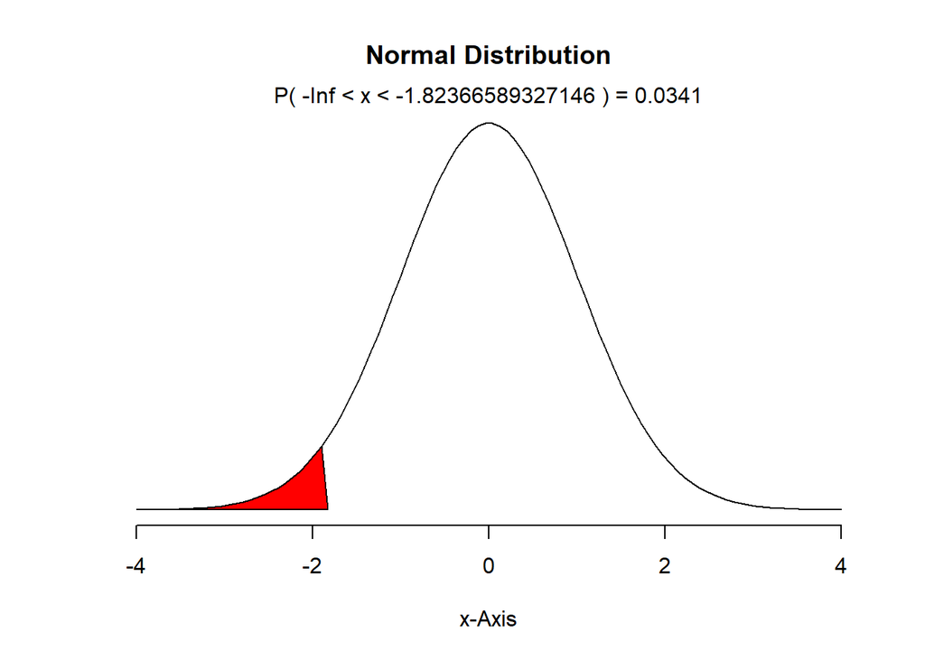

```r
normalPlot(bounds = c(-Inf, z))
```

3. Interpret the p-value in context of the hypothesis test and the data.

### Answer:

4. Calculate a 90% confidence interval for the average age at which gifted children first count to 10 successfully.

### Answer:

```r
l = 30.69-1.65*4.31
l
```

```
## [1] 23.5785
```

```r
u = 30.69+1.65*4.31
u
```

```
## [1] 37.8015
```

5. Do your results from the hypothesis test and the confidence interval agree? Explain.

### Question 4.26

1. Perform a hypothesis test to evaluate if these data provide convincing evidence that the average IQ of mothers of gifted children is different than the average IQ for the population at large, which is 100. Use a significance level of 0.10.

### Answer:

```r
z <- (118.2 - 100) / 6.5
z
```

```
## [1] 2.8
```

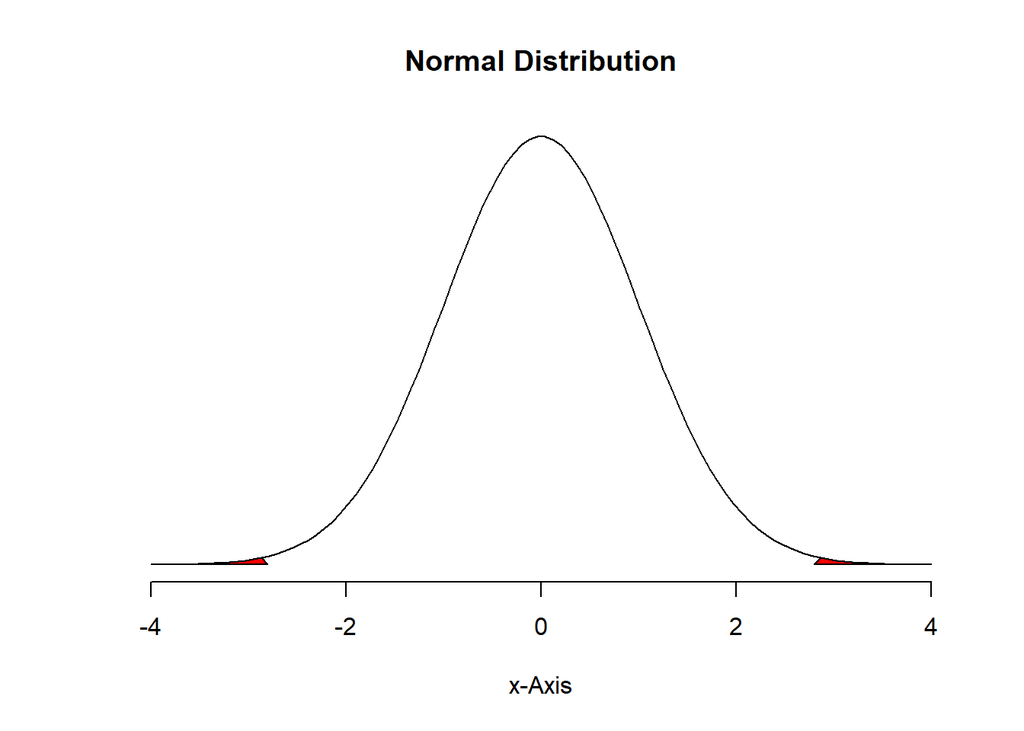

```r
normalPlot(mean = 0, sd = 1, bounds = c(-z,z), tails = TRUE)
```

```r
p = 1-0.995
p
```

```
## [1] 0.005
```

2. Calculate a 90% confidence interval for the average IQ of mothers of gifted children.

### Answer:

```r
l = 118.2-1.65*6.5
l
```

```
## [1] 107.475
```

```r
u = 118.2+1.65*6.5
u
```

```
## [1] 128.925
```

3. Do your results from the hypothesis test and the confidence interval agree? Explain.

### Answer:

#### Yes they agree they fall in 90% confidence interval.

### Question 4.34

4.34 CLT. Define the term “sampling distribution” of the mean, and describe how the shape, center, and spread of the sampling distribution of the mean change as sample size increases.

### Answer:

#### A sampling distribution can be thought of as a relative frequency distribution with a very large number of samples. More precisely, a relative frequency distribution approaches the sampling distribution as the number of samples approaches infinity. When a variable is discrete, the heights of the distribution are probabilities. When a variable is continuous, the class intervals have no width and and the heights of the distribution are probability densities.

#### Source: http://onlinestatbook.com/2/sampling_distributions/samp_dist_mean.html

### Question 4.35

4.35 Housing prices. A housing survey was conducted to determine the price of a typical home in Topanga, CA. The mean price of a house was roughly $1.3 million with a standard deviation of $300,000. There were no houses listed below $600,000 but a few houses above $3 million.

### Answer:

1. Is the distribution of housing prices in Topanga symmetric, right skewed, or left skewed? Hint: Sketch the distribution.

### Answer:

2. Would you expect most houses in Topanga to cost more or less than $1.3 million?

### Answer:

3. Can we estimate the probability that a randomly chosen house in Topanga costs more than $1.4 million using the normal distribution?

### Answer:

4. What is the probability that the mean of 60 randomly chosen houses in Topanga is more than $1.4 million?

### Answer:

5. How would doubling the sample size a???ect the standard deviation of the mean?

### Answer:

### Question 4.40

4.40 CFLBs. A manufacturer of compact fluorescent light bulbs advertises that the distribution of the lifespans of these light bulbs is nearly normal with a mean of 9,000 hours and a standard deviation of 1,000 hours.

1. What is the probability that a randomly chosen light bulb lasts more than 10,500 hours?

### Answer:

```r
z = ((10500 - 9000) / 1000)
z
```

```
## [1] 1.5
```

```r
p = 1 - pnorm(z)

#probability that a randomly chosen light bulb lasts more than 10,500 hours
p
```

```
## [1] 0.0668072
```

2. Describe the distribution of the mean lifespan of 15 light bulbs.

### Answer:

```r
1000/sqrt(15)
```

```
## [1] 258.1989
```

3. What is the probability that the mean lifespan of 15 randomly chosen light bulbs is more than 10,500 hours?

### Answer:

```r
z1 <- 1500/(1000/sqrt(15))
z1
```

```
## [1] 5.809475
```

```r
p1 = 1 - pnorm(z1)
p1
```

```
## [1] 3.133452e-09
```

4. Sketch the two distributions (population and sampling) on the same scale.

### Answer:

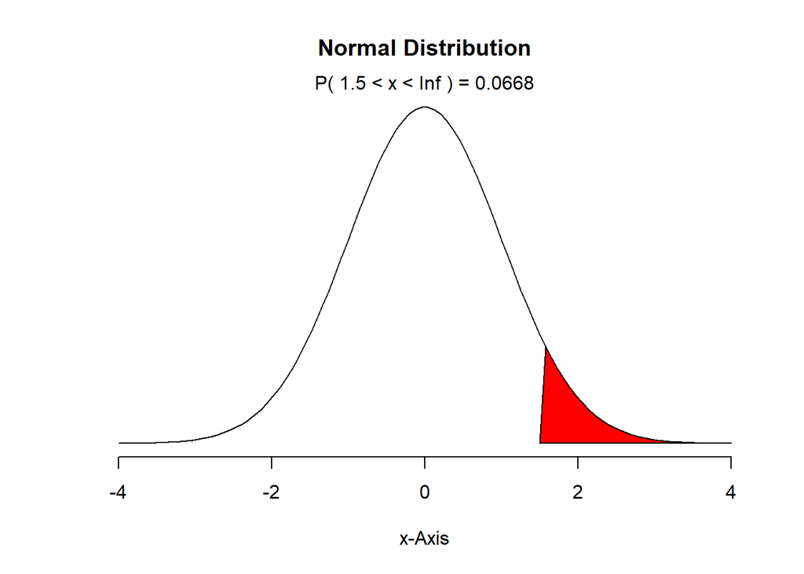

```r
normalPlot(bounds = c(z, Inf))
```

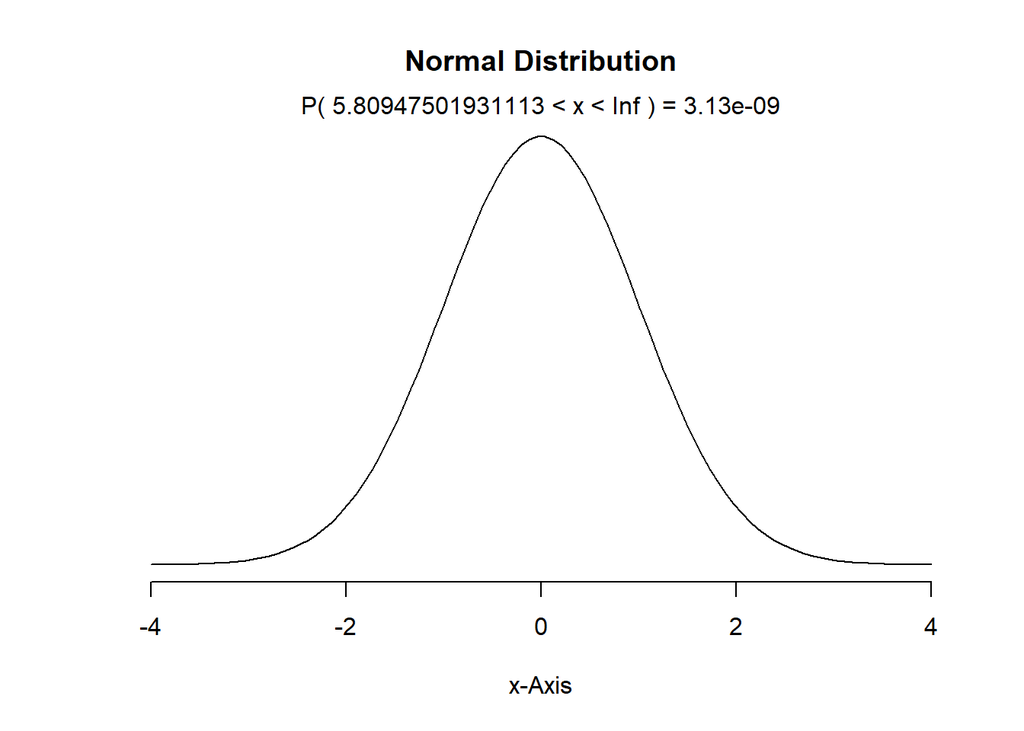

```r
normalPlot(bounds = c(z1, Inf))
```

5. Could you estimate the probabilities from parts (a) and (c) if the lifespans of light bulbs had a skewed distribution?

### Answer:

#### Probability: 0.0668072 and 3.133452e-09

### Question 4.48

4.48 Same observation, di???erent sample size. Suppose you conduct a hypothesis test based on a sample where the sample size is n = 50, and arrive at a p-value of 0.08. You then refer back to your notes and discover that you made a careless mistake, the sample size should have been n = 500. Will your p-value increase, decrease, or stay the same? Explain.

### Answer:

#### p value will decrease as sample size increases